# Fatimah_HW6

### Student Name: Fatimah Abdullahi

```python
!pip install fuzzywuzzy
!pip install wordcloud
```

```python
import pandas as pd
import numpy as np
import altair as alt
import matplotlib.pyplot as plt
from vega_datasets import data

from fuzzywuzzy import fuzz
from fuzzywuzzy import process

from wordcloud import WordCloud
from PIL import Image
```

### Part 1: Text Improvement

Return to an early assignment submission that you have made (just one plot). Reproduce it here. Then, create a *revised* version that is the best possible use of text. Make sure to use proper axis labels, tick labels, legend items, title, and subtitle if applicable. Include a descriptive general-audience caption that contains all necessary information to understand and interpret the plot.

Refer to the customization and saving demo notebook for syntax help.

```python
dataurl = 'http://lib.stat.cmu.edu/datasets/colleges/usnews.data'
college = pd.read_csv(dataurl,
                       na_values='*',
                       names = ['FICE', 'College','State','Private','MathSAT','VerbalSAT','CombinedSAT','ACT',
                                'Q1Math','Q3Math','Q1Verbal','Q3Verbal','Q1ACT','Q3ACT',
                               'Applied','Accepted','Enrolled','Top10HS','Top25HS','FullTimeUG','PartTimeUG',
                               'InStateTuition','OutOfStateTuition','RoomBoardCost','RoomCost','BoardCost',
                               'ExtraFees','BookFees','PersonalFees',
                               'PhDFaculty','TerminalFaculty','StuFacRatio','AlumniDonate','SpendPerStudent','GradRate'])
college.head()
```

|  | FICE | College | State | Private | MathSAT | VerbalSAT | CombinedSAT | ACT | Q1Math | Q3Math | ... | BoardCost | ExtraFees | BookFees | PersonalFees | PhDFaculty | TerminalFaculty | StuFacRatio | AlumniDonate | SpendPerStudent | GradRate |
| --- | --- | --- | --- | --- | --- | --- | --- | --- | --- | --- | --- | --- | --- | --- | --- | --- | --- | --- | --- | --- | --- |
| 0 | 1061 | Alaska Pacific University | AK | 2 | 490.0 | 482.0 | 972.0 | 20.0 | 440.0 | 530.0 | ... | 2500.0 | 130.0 | 800.0 | 1500.0 | 76.0 | 72.0 | 11.9 | 2.0 | 10922.0 | 15.0 |
| 1 | 1063 | University of Alaska at Fairbanks | AK | 1 | 499.0 | 462.0 | 961.0 | 22.0 | NaN | NaN | ... | 1790.0 | 155.0 | 650.0 | 2304.0 | 67.0 | NaN | 10.0 | 8.0 | 11935.0 | NaN |
| 2 | 1065 | University of Alaska Southeast | AK | 1 | NaN | NaN | NaN | NaN | NaN | NaN | ... | 2250.0 | 34.0 | 500.0 | 1162.0 | 39.0 | 51.0 | 9.5 | NaN | 9584.0 | 39.0 |
| 3 | 11462 | University of Alaska at Anchorage | AK | 1 | 459.0 | 422.0 | 881.0 | 20.0 | NaN | NaN | ... | 2520.0 | 114.0 | 580.0 | 1260.0 | 48.0 | NaN | 13.7 | 6.0 | 8046.0 | NaN |
| 4 | 1002 | Alabama Agri. & Mech. Univ. | AL | 1 | NaN | NaN | NaN | 17.0 | NaN | NaN | ... | 1442.0 | 155.0 | 500.0 | 850.0 | 53.0 | 53.0 | 14.3 | NaN | 7043.0 | 40.0 |

5 rows × 35 columns

```python
p1orig = alt.Chart(college).mark_circle(opacity=0.5, size=40).encode(
    alt.X('AcceptanceRate:Q',
          title='Acceptance Rate(%)',
          scale=alt.Scale(domain=[100,0])),
    alt.Y('Top10HS:Q',
          title='% Students from Top 10% of High School Class')
).transform_calculate(
    AcceptanceRate = 'datum.Accepted/datum.Applied * 100'
).properties(
    width=500,
    height=300,
    title='Acceptance Rate vs % Students in Top 10% of High School Class'
)

p1updated = alt.Chart(college).mark_circle(opacity=0.5, size=40).encode(
    alt.X('AcceptanceRate:Q',
          title='Acceptance Rate(%)',
          scale=alt.Scale(domain=[1,0]),
          axis=alt.Axis(format='%')),
    alt.Y('Top10HSFrac:Q',
          title='Students from Top 10% of HS Class',
          axis=alt.Axis(format='%'))
).transform_calculate(
    AcceptanceRate = 'datum.Accepted/datum.Applied'
).transform_calculate(
    Top10HSFrac = 'datum.Top10HS / 100'
).properties(
    width=500,
    height=300,
    title=alt.Title(
        "More selective Schools Attract Top-performing Students ",
        subtitle=[" Schools with lower acceptance rates tend to enroll",
                  "a higher proportion of students from the top 10% of their high school class."],
        anchor='start',
        frame='group',
        orient='bottom',
        offset=15
    )
)

(p1orig | p1updated).resolve_scale(color='independent')
```

[interactive chart not shown]

### Part 2: Data Exploration

Step 1:

Make a word cloud of the names and/or breeds. Be sure to apply string manipulation if necessary to show the data accurately.

```python
pets = pd.read_csv('https://data.seattle.gov/resource/jguv-t9rb.csv?$limit=10000')
pets.head()
```

|  | license_issue_date | license_number | animal_s_name | species | primary_breed | secondary_breed | zip_code |
| --- | --- | --- | --- | --- | --- | --- | --- |
| 0 | 2015-12-18T00:00:00.000 | S107948 | Zen | Cat | Domestic Longhair | Mix | 98117.0 |
| 1 | 2016-06-14T00:00:00.000 | S116503 | Misty | Cat | Siberian | NaN | 98117.0 |
| 2 | 2016-08-04T00:00:00.000 | S119301 | Lyra | Cat | Mix | NaN | 98121.0 |
| 3 | 2020-11-20T00:00:00.000 | 077412 | Gemma | Cat | Siamese | American Shorthair | 98126.0 |
| 4 | 2022-02-10T00:00:00.000 | S149283 | Edgar | Cat | Domestic Shorthair | Mix | 98126.0 |

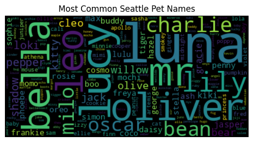

```python
name_text = ' '.join(pets['animal_s_name'].astype(str).str.lower().str.strip())

wordcloud = WordCloud().generate(name_text)
plt.imshow(wordcloud, interpolation='bilinear')
plt.axis("off")
plt.title("Most Common Seattle Pet Names")
plt.show()
```

#### Step 2: Explore the Data

Explore the data by considering the following questions:

- How many unique names are there?
- Pick one name that might have multiple spellings. Are there similar names that are spelled differently? Use fuzzy matching to see which names might be similar.
- How *many* names does each pet have? Is there a pattern you can pull out from that?
- Do any names stand out to you? For example, are there patterns in using certian prefixes to names, or name endings?
- Are there any common terms used in the breeds of the pets?

You are welcome to explore other patterns as well!

**Leave all your exploration steps here to show what you looked at, but be sure to clean up your code to show a final version of each exploration.**

```python
# How many unique names are there?
print("Unique names:"), pets['animal_s_name'].nunique()
```

```
Unique names:
```

```
(None, 5110)
```

```python
# How many words in each name?
print(pets['animal_s_name'].str.split(' ').str.len().head(10))

# Get just the first word of each name
print("\nFirst word of each name:")
print(pets['animal_s_name'].str.split(' ').str.get(0).head(10))

# Check which names contain formal titles
print("\nNames containing 'Mr':", pets['animal_s_name'].str.contains('Mr', na=False).sum())
print("Names containing 'Sir':", pets['animal_s_name'].str.contains('Sir', na=False).sum())
print("Names containing 'Princess':", pets['animal_s_name'].str.contains('Princess', na=False).sum())

# Extract the formal title from names
print("\nExtracted titles:")
has_title = pets['animal_s_name'].str.contains('Mr|Sir|Princess|Lady|King|Queen|Captain', na=False)
print(pets[has_title]['animal_s_name'].str.extract('(Mr|Sir|Princess|Lady|King|Queen|Captain)'))


# Check common breed terms
print("\nDomestic breeds:", pets['primary_breed'].str.contains('Domestic', na=False).sum())
print("Mix breeds:", pets['primary_breed'].str.contains('Mix', na=False).sum())

# Fuzzy match names similar to 'Bella'
all_names = pets['animal_s_name'].unique().tolist()
print("\nFuzzy matches for 'Bella':")
print(process.extract("Bella", all_names, limit=5))
```

```
0    1.0
1    1.0
2    1.0
3    1.0
4    1.0
5    1.0
6    1.0
7    1.0
8    1.0
9    1.0
Name: animal_s_name, dtype: float64

First word of each name:
0         Zen
1       Misty
2        Lyra
3       Gemma
4       Edgar
5       Emily
6        Taro
7      Wilbur
8        Bala
9    Sherlock
Name: animal_s_name, dtype: object

Names containing 'Mr': 45
Names containing 'Sir': 19
Names containing 'Princess': 16

Extracted titles:
             0
76          Mr
111        Sir
171         Mr
202   Princess
299       Lady
...        ...
9449   Captain
9504       Sir
9595        Mr
9784   Captain
9974       Sir

[109 rows x 1 columns]

Domestic breeds: 7258
Mix breeds: 291

Fuzzy matches for 'Bella':
[('Bella', 100), ('Junie Bella', 90), ('Bella Jane', 90), ('Bel', 90), ('Annabella', 90)]
```

#### Step 3: Make a Plot

Pick an interesting patterns that you found in your exploration above. Make a well-considered plot of this pattern. It does not need to be groundbreaking, but make sure it uses some kind of text manipulation from the above data. It should not be a word cloud but a regular Altair graphic (line, bar, scatterplot, etc).

**What one-sentence conclusion should we draw from this plot?**

> STUDENT RESPONSE

"Mr." is the most popular formal title given to Seattle pets, appearing more than twice as often as the next most common title "Sir."

```python
#Extarct formal Titles from names
has_title = pets['animal_s_name'].str.contains('Mr|Sir|Princess|Lady|King|Queen|Captain', na=False)
pets['prefix'] = pets[has_title]['animal_s_name'].str.extract('(Mr|Sir|Princess|Lady|King|Queen|Captain)')
prefix_counts = pets['prefix'].value_counts().reset_index()
prefix_counts.columns = ['prefix', 'count']

# Which formal titles are most common in pet names
alt.Chart(prefix_counts).mark_bar().encode(
    alt.X('prefix:N', title='Name Title/Prefix',
          axis=alt.Axis(labelAngle=0)),
    alt.Y('count:Q', title='Number of Pets'),
    alt.Color('prefix:N', legend=None)
).properties(
    width=400,
    height=300,
    title='Which Formal Titles Are Most Popular in Seattle Pet Names?'
)
```

[interactive chart not shown]

#### Step 4: Perfect and Save Your Plot

Take your plot from above and make it beautiful. Add a descriptive title, subtitle, and axes labels. Edit the fonts and styles to be attractive and well-sized. Add alt-text using the `description` argument and make sure it describes the data behind the plot.

```python
final_chart = alt.Chart(prefix_counts).mark_bar().encode(
    alt.X('prefix:N',
          title='Name Title/Prefix',
          sort='y',
          axis=alt.Axis(labelAngle=0)),
    alt.Y('count:Q',
          title='Number of Pets'),
    alt.Color('prefix:N', legend=None)
).properties(
    width=400,
    height=300,
    title=alt.Title(
        "Formal Titles in Seattle Pet Names",
        subtitle=["'Mr.' is the most popular formal title for pets,",
                  "followed by 'Sir' and 'Princess'."],
        anchor='start',
        frame='group',
        orient='bottom',
        offset=15
    ),
    description="Bar chart showing how frequently each formal title such as Mr., Sir, Princess, Captain appears in Seattle pet names. Mr. is the most common."
).configure_axis(
    titleFontSize=14,
    labelFontSize=12
).configure_view(
    stroke=None
)


final_chart
```

[interactive chart not shown]